# Lecture 15

2026-05-19

# Exploratory Data Analysis

## Introduction

- This is a quick review/discussion of exploratory data analysis.
- Something you are expected to do to your data for Project 3
- If you are still looking for data, some quick advice on what you should be looking for

## A Data Set

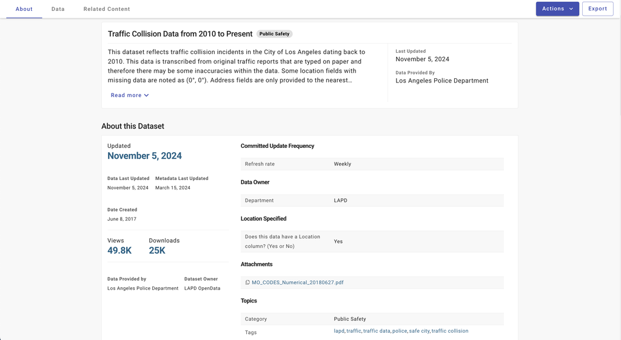

## A Data Set - Codebook

[figure not shown]

## A Data Set - Codebook

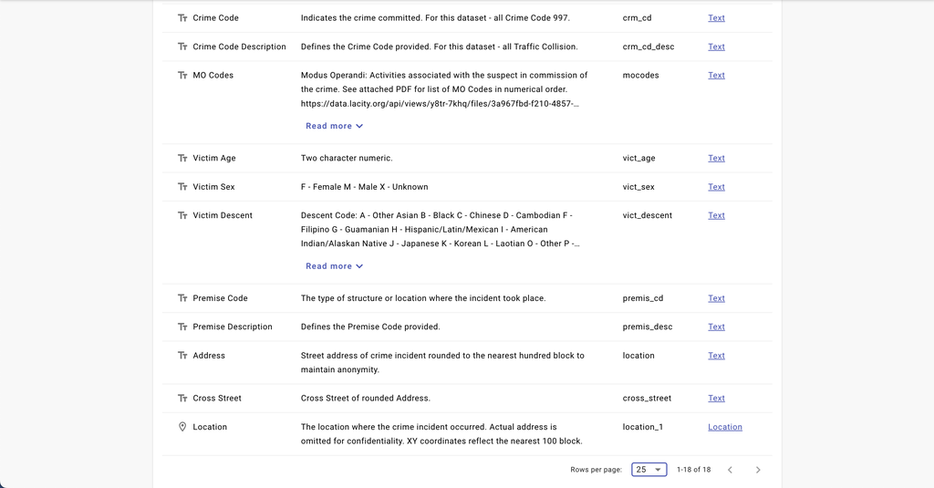

## A look at the data itself

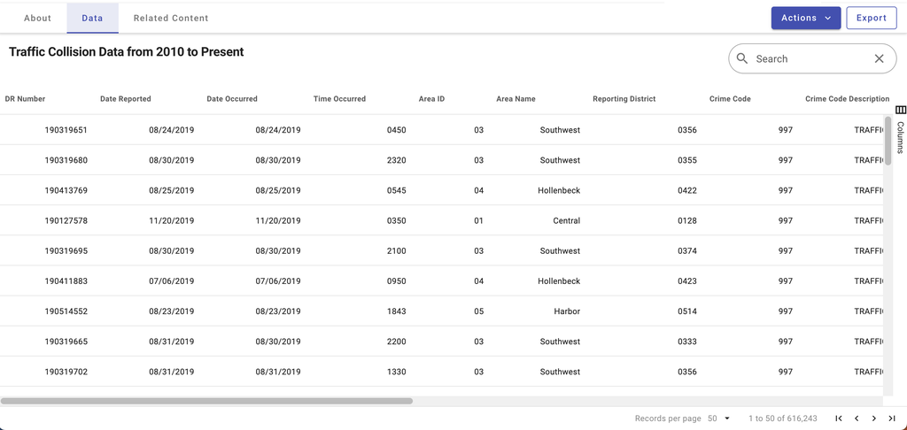

## What is EDA?

- Exploratory Data Analysis (EDA) is “way” to prepare for data analysis and the problem solving/modeling that uses a variety of techniques to
  - gain understanding of a data set
  - discern/extract variables that relate to a larger problem
  - identify/document outliers and anomalies (could be a problem, could be a future trend)
  - test assumptions (e.g., normality, equality, etc.)
  - discover underlying interrelationships (not really Stats 20)
  - develop models (not really Stats 20)
- EDA is an approach to data analysis that does not start with assumptions about what kind of model the data follow but lets the data itself to reveal its underlying structure and model,

## Suggested initial approach

Document the general characteristics of the data, try to obtain confirmation

- How many records (typically rows – another name?)
- How many fields (typically columns)
- What data types are present (Numeric or Non-Numeric)
- How many unique values are present in each variable
- Modes (most common value)
- Extent of missing (NA for numeric, blanks for non-numeric)

## Analysis Tools

- Visualizations
- Tables/Tabulations (typically non-numeric)
- (numeric) Summary Statistics

## Non-Numeric Visualizations

- barplot (standard, stacked, side-by-side)
- waffle chart (grid of percentages)
- mosaic plot (visualizing a two way table)
- pie chart (consider a [donut instead](https://r-graph-gallery.com/128-ring-or-donut-plot.html) )

## Numeric Visualizations

- histogram (look like bars)
- densities (smoothed)
- dot_plots (best for small datasets)
- scatterplot (two variables)

## Combined (numeric & not)

- boxplots (typically one numeric, one non-numeric)
- maps (geographic, heat)

## Numeric Summaries

- for non-numeric: tabulations
- for numeric: measures of center, measure of spread

## Issues: Anomalies/Outliers

```
+ Continuous - skewness, outliers (> $|3 \sigma|$)
+ Plots/visualizations - look for unusual observations
+ Thresholds for outliers - take a common sense approach (is the value reasonable)
```

## Issues: Missing Data

- Ask yourself whether the level/extent of missingness is reasonable given the data
  - e.g., stock market data vs. a survey of the homeless
- There is no agreed upon perfect amount, less than 10% is probably negligible
- BUT this is truly not a matter of amount, but think instead about pattern and the mechanism by which the missing arises.
- Imputation is possible but typically beyond the expectations undergraduate courses

## A little advanced

- Not for Stats 20 but
  - time series data (e.g., stock prices over time) has specialized plots and models
  - complex multivariate data might use methods such as Principal Components/clustering (101C)

## Common to all

Regardless of what is to be done, there are things you always do

- Try to locate its data dictionary
- Explore the Data
  - Visualizations and Numeric Summaries
  - Univariate then bivariate and beyond (multivariate analysis)
  - Examine Subgroups within the data
  - is it specialized? Time series or repeated measures?
  - Spatial patterns?

## Results of a solid EDA

- Thorough exploration of the data helpps us start to formulate hypotheses about the relationships between variables
- Exploration guides further analysis as EDA helps with cleaning and transforming data to make it usable for complex analyses like machine learning modeling.
- Make informed decisions using insights gained from EDA refines additional analysis, model selection, and beyond.

## Extra: Adding Visualizations/graphics

- ggplot simplifies/unifies data visualizations in R

```r
library(ggplot2)
library(ggthemes)
## install.packages("remotes")
## remotes::install_github("hrbrmstr/waffle")
library(waffle)
library(vcd)
library(ggridges)
library(lubridate)
library(sf)
library(dplyr)
library(tidyr)
library(knitr)
library(kableExtra)
load("collison.RData") # apologies for the typo
```

## Non-numeric Barplot (counts)

```r
ggplot(collison, aes(x = Victim_Sex, fill = any_injury)) +
  geom_bar(stat='count', color = 'black') + # default is stat='count'
  facet_wrap(~Victim_Descent, nrow = 1) +
  labs(y = 'Count of Collisons',
       x = 'Victim Descent',
       title = 'Collisons by Gender & Descent') +
    theme_fivethirtyeight()
```

## Result Non-numeric Barplot (counts)

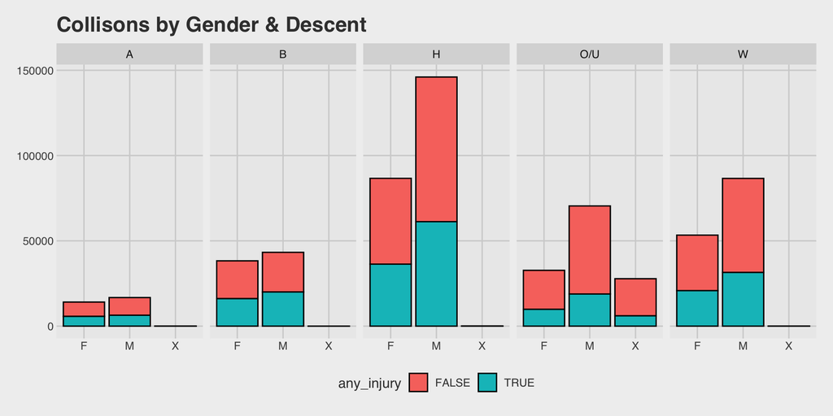

## Same Barplot (proportions)

```r
ggplot(collison, aes(x = Victim_Sex, fill = any_injury)) +
  geom_bar(position = "fill", color = 'black') +
  facet_wrap(~Victim_Descent, nrow = 1) +
  labs(y = 'Proportion of Collisons with Any Injury',
       x = 'Victim Descent',
       title = 'Injury Collisons by Gender & Descent') +
    theme_fivethirtyeight()
```

## Result Same Barplot (proportions)

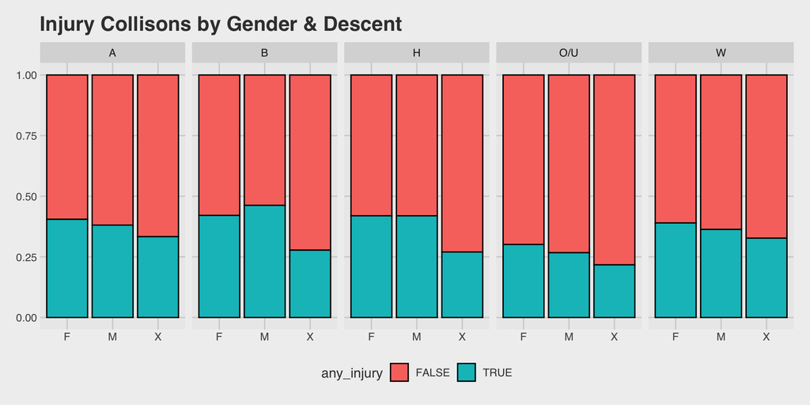

## Pie Charts

- People love these but please be wise about them, they tend to distort area.
- We also need several “tricks” to make it happen, this can be difficult to remember as they are not very intuitive.

```r
ggplot(collison, aes(x = factor(1), fill=factor(Victim_Descent))) +
  geom_bar(width=1, color = "white") +
  coord_radial(theta="y", expand=FALSE) +
  theme_void() +
  labs(fill = "Victim Descent") # Renames the legend title
```

## Result: Pie Charts

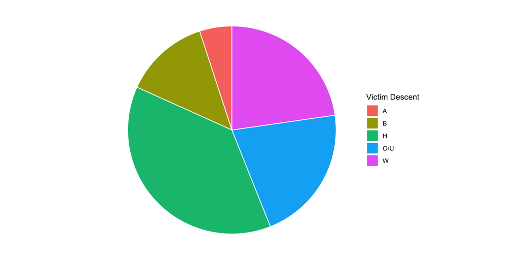

## Result: Pie Chart Comparison

- The criticism of pie charts is about comparison
- Experiments show that viewers are likely make bad comparisons

```r
ggplot(collison, aes(x = 1, fill = factor(Victim_Descent))) +
  geom_bar(position = "fill", color = "white") +
  coord_radial(theta = "y", expand = FALSE) +
  facet_wrap(~any_injury) +
  theme_void() +
  theme(legend.position = "bottom", plot.title = element_text(hjust = 0.5)) +
  labs(title="Distribution of Victim Descent by Injury Status", fill = "Victim_Descent")
```

## Result: Pie Chart Comparison

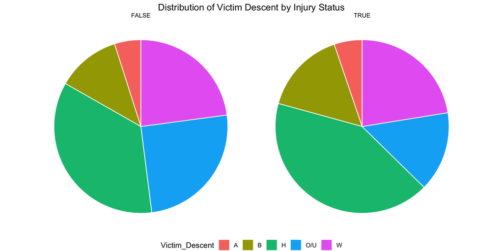

## Donut Plot Comparison

- If you must have pies, choose a donut plot or something like horizontal stacked bar to help viewers with comparisons

```r
ggplot(collison, aes(x = 2, fill=factor(Victim_Descent))) +
  geom_bar(position = "fill", color = "white") +
  coord_radial(theta="y", expand=FALSE) +
  facet_wrap(~any_injury) +
  xlim(0.5, 2.5) +
  theme_void() +
  theme(legend.position = "bottom", plot.title = element_text(hjust = 0.5)) +
  labs(title="Distribution of Victim Descent by Injury Status", fill = "Victim_Descent") # Renames the legend title
```

## Result: Donut Plot Comparison

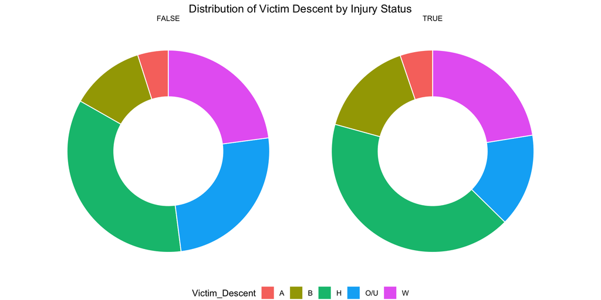

## Non-Numeric Waffle Chart

```r
x <- table(collison$Victim_Descent,
           collison$Victim_Sex) |> as.data.frame()
names(x) <- c("Descent", "Sex", "Count")
ggplot(data = x, aes(fill=Sex, values=Count)) +
  geom_waffle(color = "white",
              make_proportional = TRUE) +
  facet_wrap(~Descent, ncol=1) +
  theme_void()
```

## Result: Non-Numeric Waffle Chart

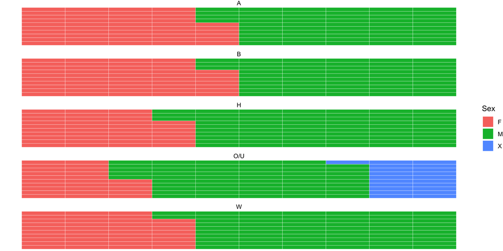

## Non-Numeric Mosaic Plot

- Not in ggplot but in the package “vcd”
- Used for two non-numeric variables

```r
nomissing <- na.omit(collison[, 12:13])
x <- table(nomissing$Victim_Descent,
           nomissing$Victim_Sex)
names(dimnames(x)) <- c("Victim_Descent", "Victim_Sex")
mosaic(x, shade = TRUE, legend=FALSE)
```

## Non-Numeric Mosaic Plot

- Not in ggplot but in the package “vcd”

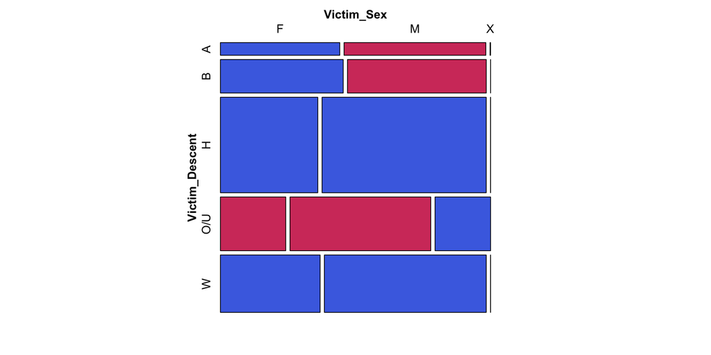

## Non-Numeric and Numeric - Ridgeline

- An alternative to the boxplot

```r
ggplot(collison, aes(x = Victim_Age, y = Victim_Descent, fill = Victim_Descent)) +
  geom_density_ridges() +
  theme_ridges() +
  theme(legend.position = "none")
```

## Result - Ridgeline

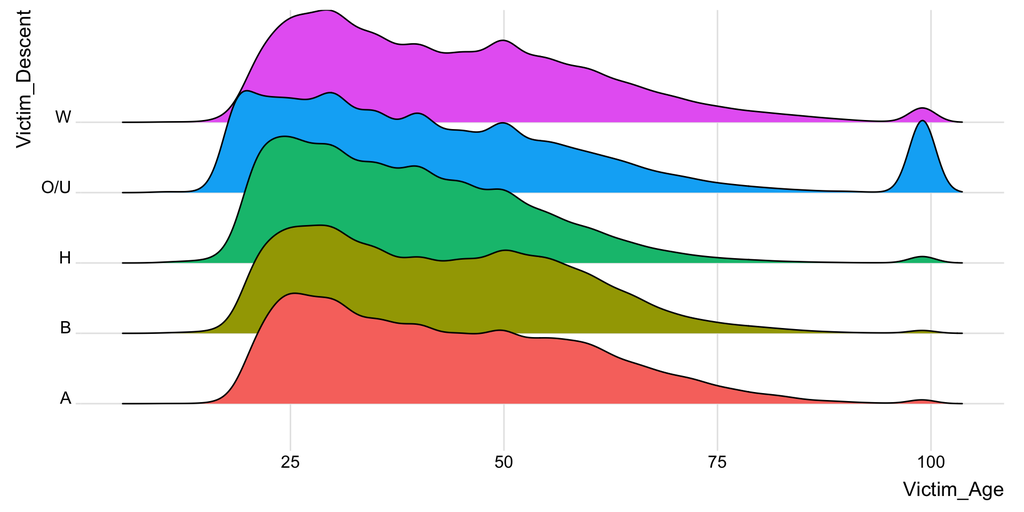

## Heatmap Data Prep

- Data wrangling/munging before visualizations and descriptive stats can be useful

```r
collison$YEAR <- year(collison$Date_Occurred)
collison$MONTH <- month(collison$Date_Occurred)
collison$WoY <- week(collison$Date_Occurred)
collison$DoW <- wday(collison$Date_Occurred)
col_tabled <- table(collison$YEAR,
           collison$WoY,
           collison$DoW) |> as.data.frame()
names(col_tabled) <- c("YEAR", "WEEK", "DOW", "n")
col_tabled[,1:3] <- lapply(col_tabled[,1:3], function(i) as.numeric(levels(i))[i])
head(col_tabled)
```

```
  YEAR WEEK DOW   n
1 2010    1   1  99
2 2011    1   1  90
3 2012    1   1 101
4 2013    1   1  93
5 2014    1   1  98
6 2015    1   1 113
```

## Heat Map Code

```r
col_tabled |>
  filter(YEAR > 2016 & YEAR < 2021) |>
  ggplot(aes(x= WEEK, y = DOW, fill = n)) +
        geom_tile(color = "white") +
        facet_wrap(~YEAR, ncol = 1) +
  scale_fill_gradientn(colours = c("grey95","#B5E384", "#FFFFBD","#FFAE63","#D61818"))
```

## Heat Map Result

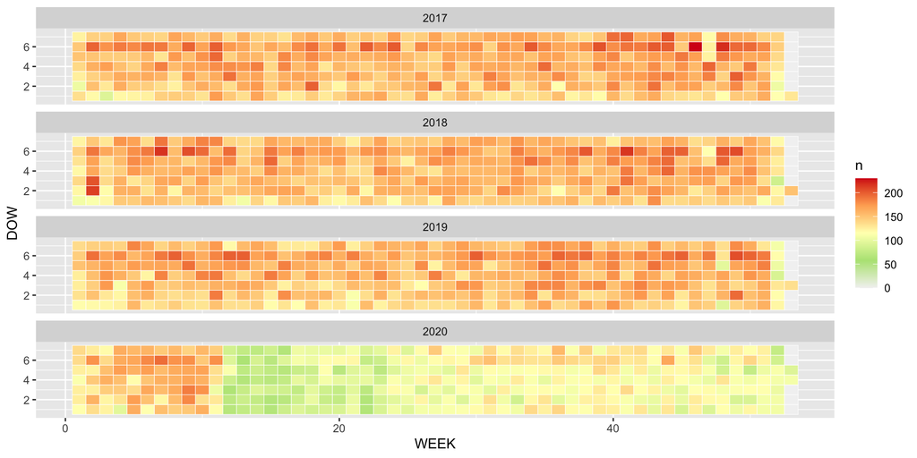

## Heatmap 2 - prep

- Heatmaps do not need to be completely numeric data
- Here we use area names

```r
col_tabled <- table(collison$Area_Name,
           collison$YEAR) |> as.data.frame()
names(col_tabled) <- c("Area_Name", "YEAR", "n")
col_tabled$YEAR <- as.numeric(levels(col_tabled$YEAR))[col_tabled$YEAR]
head(col_tabled)
```

```
    Area_Name YEAR    n
1 77th Street 2010 2710
2     Central 2010 1654
3  Devonshire 2010 2241
4    Foothill 2010 1624
5      Harbor 2010 1787
6  Hollenbeck 2010 1577
```

## Heatmap 2

```r
col_tabled |>
  filter(YEAR > 2016 & YEAR < 2021) |>
  ggplot(aes(x= YEAR, y = Area_Name, fill = n)) +
        geom_tile(color = "white") +
  scale_fill_gradientn(colours = c("grey95","#B5E384", "#FFFFBD","#FFAE63","#D61818"))
```

[figure not shown]

# Break

## Activity Attendance

### Please Greet Your Neighbor(s)

- Practice greeting others in a safe environment. Unitl it becomes natural.
- Reminder: You will not receive credit if it’s only you in the photo, please refrain from photoshopping/editing photos
- Reminder: You need to upload the photo for full credit before the next Tuesday’s lecture. Part or no credit otherwise.
- Please try to greet & meet a different classmate, take a photograph.

# Tables

## Tables

- table() is found in base R
- One-way, two-way, n-way
- One and two way are common and useful
- n-way are interesting but need lots of data and can get very complicated very quickly.

## One-way

- table() and some vector, numeric or non-numeric, the number of unique values is most important.

```r
table(collison$Victim_Descent)
```

```
     A      B      H    O/U      W
 30923  81564 232777 130981 139998
```

```r
table(collison$Victim_Descent) |> sort()
```

```
     A      B    O/U      W      H
 30923  81564 130981 139998 232777
```

## Add formatting

- make a table more attractive by using kable() from the knitr library.

```r
table(collison$Victim_Descent) |>
  kable(col.names=c("Descent", "Count"),
        format.args = list(big.mark = ","))
```

| Descent | Count |
| --- | --- |
| A | 30,923 |
| B | 81,564 |
| H | 232,777 |
| O/U | 130,981 |
| W | 139,998 |

## Two-way

- table() and two vectors, numeric or non-numeric, the total number of unique values is most important.

```r
table(collison$Victim_Descent, collison$Victim_Sex)
```

```
           F      M      X
  A    14109  16754     60
  B    38281  43265     18
  H    86643 146034    100
  O/U  32709  70468  27804
  W    53344  86599     55
```

## Add formatting

- The library kableExtra has many more options than regular kable()
- A general rule: in print, tables should always stand on their own

```r
table(collison$Victim_Descent, collison$Victim_Sex) |>
  kable(
    booktabs = TRUE,
    align = "lccc", # left, center, center, center
    caption = "Victim Count by Descent and Sex",
    format.args = list(big.mark = ",")
  ) |>
  kable_styling(
    latex_options = c("striped", "scale_down"), # scale_down ensures it fits the page width
    full_width = FALSE # keeps whitespace from getting too large
  ) |>
  add_header_above(c("Descent Code" = 1, "Victim Sex" = 3)) |>
  column_spec(1, bold = TRUE) # Makes the row labels pop
```

## Result - Add formatting

Victim Count by Descent and Sex

| Descent Code | Victim Sex F | Victim Sex M | Victim Sex X |
| --- | --- | --- | --- |
| A | 14,109 | 16,754 | 60 |
| B | 38,281 | 43,265 | 18 |
| H | 86,643 | 146,034 | 100 |
| O/U | 32,709 | 70,468 | 27,804 |
| W | 53,344 | 86,599 | 55 |

## The tidyverse way

- A different approach is to use tidyverse, specifically dplyr with tidyr to generate new data frames(and also tables)

```r
df_wide <- collison |>
  count(Victim_Descent, Victim_Sex) |>
  pivot_wider(names_from = Victim_Descent, values_from = n)

df_wide
```

```
# A tibble: 3 × 6
  Victim_Sex     A     B      H `O/U`     W
  <chr>      <int> <int>  <int> <int> <int>
1 F          14109 38281  86643 32709 53344
2 M          16754 43265 146034 70468 86599
3 X             60    18    100 27804    55
```

## A more complex result

```r
df_large <- collison |>
  count(Premise_Description, Area_Name)

dim(df_large)
```

```
[1] 733   3
```

```r
df_large
```

```
# A tibble: 733 × 3
   Premise_Description Area_Name       n
   <chr>               <chr>       <int>
 1 AIRCRAFT            Pacific         1
 2 ALLEY               77th Street   127
 3 ALLEY               Central        48
 4 ALLEY               Devonshire     38
 5 ALLEY               Foothill       21
 6 ALLEY               Harbor        127
 7 ALLEY               Hollenbeck     47
 8 ALLEY               Hollywood      22
 9 ALLEY               Mission        44
10 ALLEY               N Hollywood    54
# ℹ 723 more rows
```

## Another complex result

- You are only limited by your imagination

```r
df_multi <- collison |>
  count(Victim_Descent, Victim_Sex, DUI, FATAL)
df_multi
```

```
# A tibble: 51 × 5
   Victim_Descent Victim_Sex DUI   FATAL     n
   <chr>          <chr>      <lgl> <lgl> <int>
 1 A              F          FALSE FALSE 13941
 2 A              F          FALSE TRUE     62
 3 A              F          TRUE  FALSE   106
 4 A              M          FALSE FALSE 16490
 5 A              M          FALSE TRUE     78
 6 A              M          TRUE  FALSE   185
 7 A              M          TRUE  TRUE      1
 8 A              X          FALSE FALSE    59
 9 A              X          TRUE  FALSE     1
10 B              F          FALSE FALSE 37795
# ℹ 41 more rows
```

## tidyverse & knitr

- Can produce all manner of customized tables

```r
kable(df_wide,
    booktabs = TRUE,
    align = "lccccc", # left, center, center, center, center, center
    caption = "Victim Count by Descent and Sex",
    format.args = list(big.mark = ",")
)
```

Victim Count by Descent and Sex

| Victim_Sex | A | B | H | O/U | W |
| --- | --- | --- | --- | --- | --- |
| F | 14,109 | 38,281 | 86,643 | 32,709 | 53,344 |
| M | 16,754 | 43,265 | 146,034 | 70,468 | 86,599 |
| X | 60 | 18 | 100 | 27,804 | 55 |

## tidyverse vs base R tables

### One Way

```r
collison |>
  count(Victim_Descent) |>
  kable()
```

| Victim_Descent | n |
| --- | --- |
| A | 30923 |
| B | 81564 |
| H | 232777 |
| O/U | 130981 |
| W | 139998 |

```r
table(collison$Victim_Descent) |> kable()
```

| Var1 | Freq |
| --- | --- |
| A | 30923 |
| B | 81564 |
| H | 232777 |
| O/U | 130981 |
| W | 139998 |

## tidyverse vs base R tables

### Two Way

```r
collison |>
  count(DUI, FATAL) |>
   kable()
```

| DUI | FATAL | n |
| --- | --- | --- |
| FALSE | FALSE | 603092 |
| FALSE | TRUE | 3124 |
| TRUE | FALSE | 9898 |
| TRUE | TRUE | 129 |

```r
table(collison$DUI, collison$FATAL)  |> kable()
```

|  | FALSE | TRUE |
| --- | --- | --- |
| FALSE | 603092 | 3124 |
| TRUE | 9898 | 129 |

## tidyverse vs base R tables

### More than Two Way

- tidyverse stacks the data

```r
collison |>
  count(Victim_Sex, DUI, FATAL)
```

```
# A tibble: 12 × 4
   Victim_Sex DUI   FATAL      n
   <chr>      <lgl> <lgl>  <int>
 1 F          FALSE FALSE 221420
 2 F          FALSE TRUE     781
 3 F          TRUE  FALSE   2848
 4 F          TRUE  TRUE      37
 5 M          FALSE FALSE 354389
 6 M          FALSE TRUE    2228
 7 M          TRUE  FALSE   6414
 8 M          TRUE  TRUE      89
 9 X          FALSE FALSE  27283
10 X          FALSE TRUE     115
11 X          TRUE  FALSE    636
12 X          TRUE  TRUE       3
```

## tidyverse vs base R tables

### More than Two Way

- base R creates arrays

```r
table(collison$Victim_Sex, collison$DUI, collison$FATAL)
```

```
, ,  = FALSE


     FALSE   TRUE
  F 221420   2848
  M 354389   6414
  X  27283    636

, ,  = TRUE


     FALSE   TRUE
  F    781     37
  M   2228     89
  X    115      3
```